# GGplot Templates For The Schratt Lab

David Colameo

14 10 2021

## Goals

Create a common guideline to create publishing-ready and standardized plots for the Schrattlab. This markdown should continuously be supplemented, so suggestions are more than welcome.

A useful website with cheatsheets for R coding in general can be found here: https://www.rstudio.com/resources/cheatsheets/

### Styling

Lets unify styling of plots and colors

```r
library(ggplot2)
library(ggpubr)
```

### Data

Load a dummy dataset called iris There are many more built-in datasets (see data() for more information)

This famous (Fisher’s or Anderson’s) iris data set gives the measurements in centimeters of the variables sepal length and width and petal length and width, respectively, for 50 flowers from each of 3 species of iris. The species are Iris setosa, versicolor, and virginica.

iris is a data frame with 150 cases (rows) and 5 variables (columns) named Sepal.Length, Sepal.Width, Petal.Length, Petal.Width, and Species.

```r
head(iris)
```

```
##   Sepal.Length Sepal.Width Petal.Length Petal.Width Species
## 1          5.1         3.5          1.4         0.2  setosa
## 2          4.9         3.0          1.4         0.2  setosa
## 3          4.7         3.2          1.3         0.2  setosa
## 4          4.6         3.1          1.5         0.2  setosa
## 5          5.0         3.6          1.4         0.2  setosa
## 6          5.4         3.9          1.7         0.4  setosa
```

```r
summary(iris)
```

```
##   Sepal.Length    Sepal.Width     Petal.Length    Petal.Width
##  Min.   :4.300   Min.   :2.000   Min.   :1.000   Min.   :0.100
##  1st Qu.:5.100   1st Qu.:2.800   1st Qu.:1.600   1st Qu.:0.300
##  Median :5.800   Median :3.000   Median :4.350   Median :1.300
##  Mean   :5.843   Mean   :3.057   Mean   :3.758   Mean   :1.199
##  3rd Qu.:6.400   3rd Qu.:3.300   3rd Qu.:5.100   3rd Qu.:1.800
##  Max.   :7.900   Max.   :4.400   Max.   :6.900   Max.   :2.500
##        Species
##  setosa    :50
##  versicolor:50
##  virginica :50
##
##
##
```

```r
ag <- function(df, cols, fun=mean) {

  df <- aggregate(df, by=as.list(df[,cols]), FUN=fun)
  return(df[, colSums(is.na(df)) != nrow(df)])


}
```

## Groundplot

Lets define a groundplot and save it in the variable p, where we can add elements on top. Lets look at different styles here.

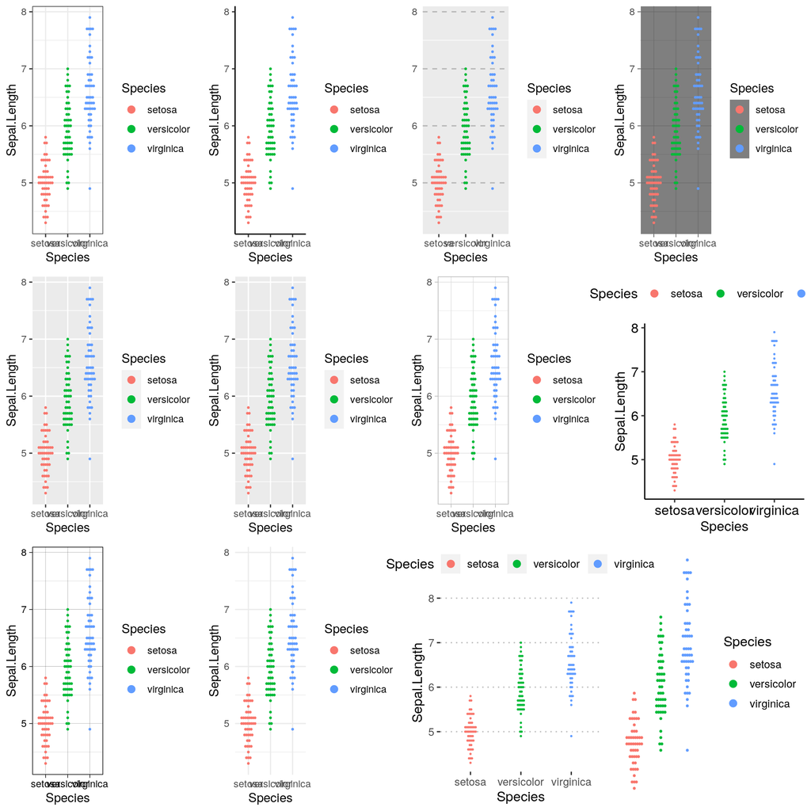

```r
p <- ggplot(iris, aes(x=Species, y=Sepal.Length, color = Species))  +
  ##adding dots here
  geom_dotplot(aes(fill = Species), binaxis='y', stackdir='center', binwidth=1/30)

ggarrange(
p + theme_bw(),
p + theme_classic(),
p + theme_cleveland(),
p + theme_dark(),
p + theme_get(),
p + theme_gray(),
p + theme_light(),
p + theme_pubr(),
p + theme_linedraw(),
p + theme_minimal(),
p + theme_pubclean(),
p + theme_transparent())
```

### Scatterplots

Scatterplots should be used for n < 5. Mean + SD

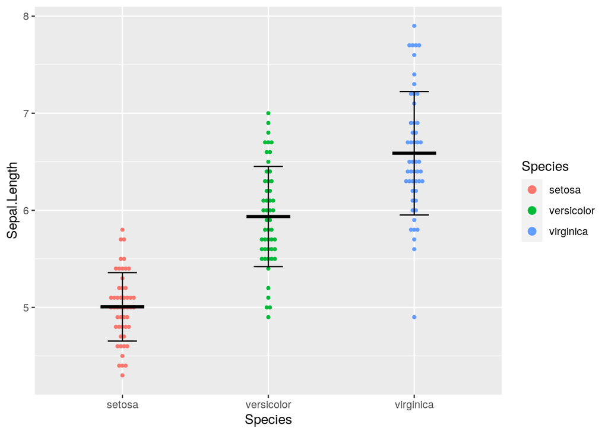

```r
p +
  ##adding errorbars here
  stat_summary(fun.data=mean_sdl, fun.args = list(mult=1),
        geom="errorbar", color="black", width=0.2) +
  ##adding mean crossbar here
  stat_summary(fun=mean, geom="crossbar", color="black", width=0.3)
```

### Boxplots

Boxplots for n>5

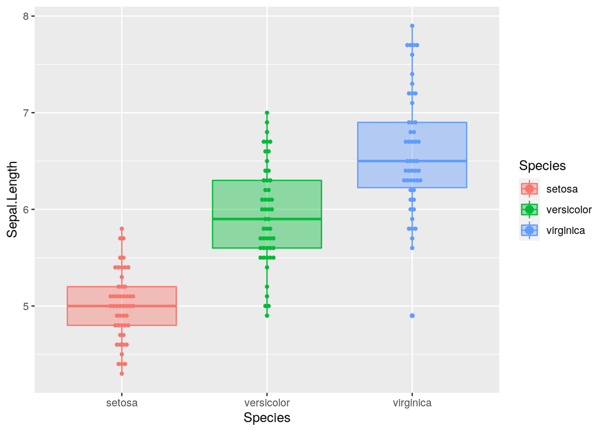

```r
p  +
  ##adding dots here
  geom_dotplot(aes(fill = Species), binaxis='y', stackdir='center', binwidth=1/30) +
  ##add boxplots here
  geom_boxplot(alpha=0.4, aes(fill = Species))
```

### Correlation Plots

Correlate two variables:

If normal distributed use Pearson otherwise non-parametric Spearman

(To be done: Styling should be adjusted to the rest of the plot)

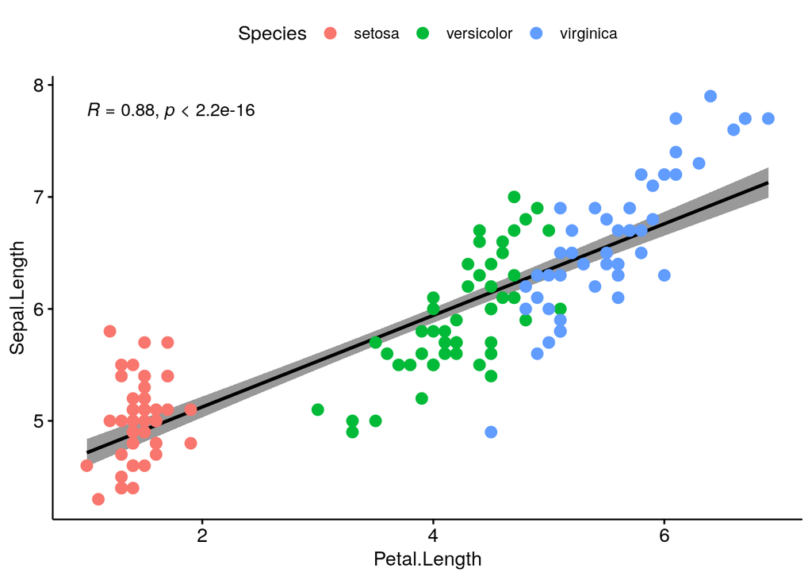

```r
ggscatter(iris, x="Petal.Length", y="Sepal.Length",
          add = "reg.line", conf.int = TRUE,
          cor.coef = TRUE, cor.method = "spearman")+ geom_point(size=3,aes(color=Species))
```

### Use more than variable

```r
library(reshape2)

long.dat <- reshape2::melt(iris, id.vars = "Species", measure.vars = c("Petal.Length", "Sepal.Length"))

head(long.dat)
```

```
##   Species     variable value
## 1  setosa Petal.Length   1.4
## 2  setosa Petal.Length   1.4
## 3  setosa Petal.Length   1.3
## 4  setosa Petal.Length   1.5
## 5  setosa Petal.Length   1.4
## 6  setosa Petal.Length   1.7
```

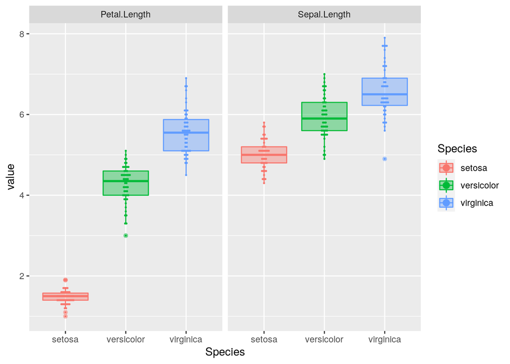

```r
ggplot(long.dat, aes(x=Species, y=value, color = Species, fill=Species))  +
  ##adding dots here
    geom_dotplot(binaxis='y', stackdir='center', binwidth=1/30) + geom_boxplot(alpha=0.4) + facet_grid(~variable, scales = "free")
```

or alternatively by changing from facet_grid from ~ variable to variable ~ .

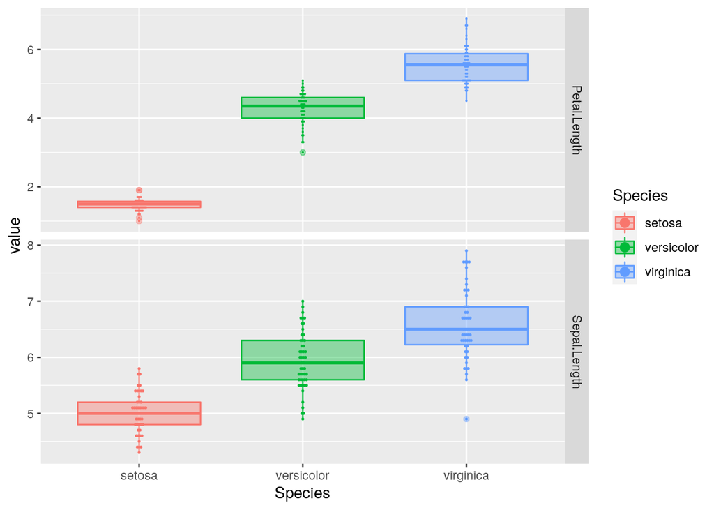

```r
ggplot(long.dat, aes(x=Species, y=value, color = Species, fill=Species))  +
  ##adding dots here
    geom_dotplot(binaxis='y', stackdir='center', binwidth=1/30) + geom_boxplot(alpha=0.4) + facet_grid(variable ~ ., scales = "free")
```

In other instances, you can also combine more than one grouping factor together like this:

- variable.x ~ variable.y
- variable.x ~ variable.y ~ variable.z

and to more fancy stuff:

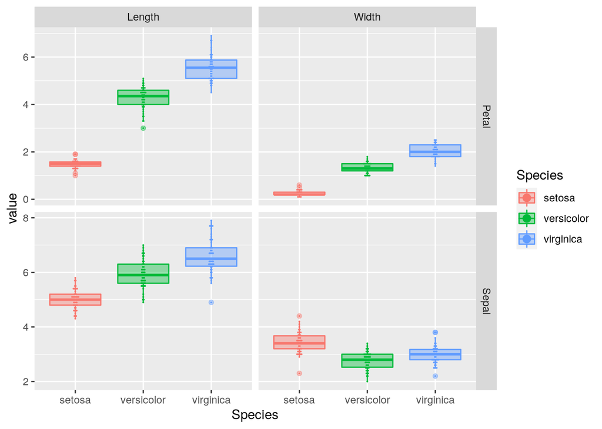

```r
library(stringr)

long.dat <- reshape2::melt(iris, id.vars = "Species")

long.dat$Leaf <- sapply(as.character(long.dat$variable), FUN= function(x){

  unlist(str_split(x, pattern="\\."))[1]

})

long.dat$Form <- sapply(as.character(long.dat$variable), FUN= function(x){

  unlist(str_split(x, pattern="\\."))[2]

})

ggplot(long.dat, aes(x=Species, y=value, color = Species, fill=Species))  +
  ##adding dots here
    geom_dotplot(binaxis='y', stackdir='center', binwidth=1/30) + geom_boxplot(alpha=0.4) + facet_grid(Leaf ~ Form, scales = "free")
```

### Grouping Inside a Single Plot

Instead of having 4 separate plots, we can also put them all together in one plot using the aesthetic mapping “group”.

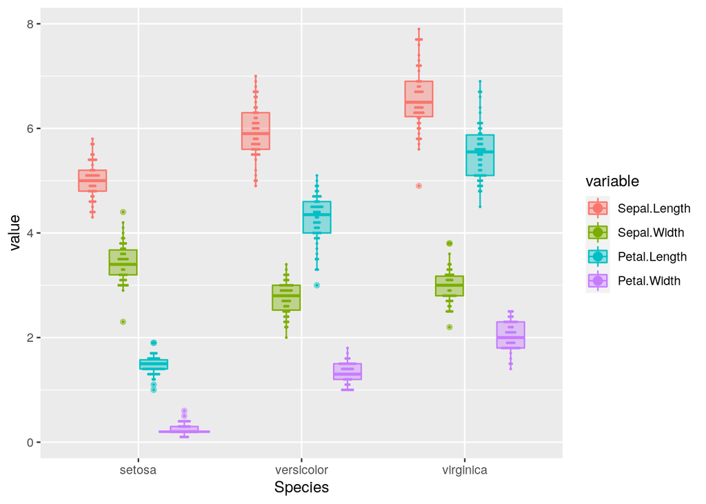

```r
ggplot(long.dat, aes(x=Species, y=value, color = variable, fill=variable, group = interaction(variable, Species)))  +
  ##adding dots here
    geom_dotplot(binaxis='y', stackdir='center', binwidth=1/30, position = position_dodge(0.75)) + geom_boxplot(alpha=0.4)
```